# L6-Problem_set_2_variables

Jeswin

27 September 2017

```r
# Loading libraries
library(ggplot2)
library(tidyr)
suppressMessages(library(dplyr))
suppressMessages(library(gridExtra))
library(hexbin)
```

## 1. Price vs x : create a scatterplot of price vs x.

```r
data("diamonds")
summary(diamonds)
```

```
##      carat               cut        color        clarity
##  Min.   :0.2000   Fair     : 1610   D: 6775   SI1    :13065
##  1st Qu.:0.4000   Good     : 4906   E: 9797   VS2    :12258
##  Median :0.7000   Very Good:12082   F: 9542   SI2    : 9194
##  Mean   :0.7979   Premium  :13791   G:11292   VS1    : 8171
##  3rd Qu.:1.0400   Ideal    :21551   H: 8304   VVS2   : 5066
##  Max.   :5.0100                     I: 5422   VVS1   : 3655
##                                     J: 2808   (Other): 2531
##      depth           table           price             x
##  Min.   :43.00   Min.   :43.00   Min.   :  326   Min.   : 0.000
##  1st Qu.:61.00   1st Qu.:56.00   1st Qu.:  950   1st Qu.: 4.710
##  Median :61.80   Median :57.00   Median : 2401   Median : 5.700
##  Mean   :61.75   Mean   :57.46   Mean   : 3933   Mean   : 5.731
##  3rd Qu.:62.50   3rd Qu.:59.00   3rd Qu.: 5324   3rd Qu.: 6.540
##  Max.   :79.00   Max.   :95.00   Max.   :18823   Max.   :10.740
##
##        y                z
##  Min.   : 0.000   Min.   : 0.000
##  1st Qu.: 4.720   1st Qu.: 2.910
##  Median : 5.710   Median : 3.530
##  Mean   : 5.735   Mean   : 3.539
##  3rd Qu.: 6.540   3rd Qu.: 4.040
##  Max.   :58.900   Max.   :31.800
##
```

```r
str(diamonds)
```

```
## Classes 'tbl_df', 'tbl' and 'data.frame':    53940 obs. of  10 variables:
##  $ carat  : num  0.23 0.21 0.23 0.29 0.31 0.24 0.24 0.26 0.22 0.23 ...
##  $ cut    : Ord.factor w/ 5 levels "Fair"<"Good"<..: 5 4 2 4 2 3 3 3 1 3 ...
##  $ color  : Ord.factor w/ 7 levels "D"<"E"<"F"<"G"<..: 2 2 2 6 7 7 6 5 2 5 ...
##  $ clarity: Ord.factor w/ 8 levels "I1"<"SI2"<"SI1"<..: 2 3 5 4 2 6 7 3 4 5 ...
##  $ depth  : num  61.5 59.8 56.9 62.4 63.3 62.8 62.3 61.9 65.1 59.4 ...
##  $ table  : num  55 61 65 58 58 57 57 55 61 61 ...
##  $ price  : int  326 326 327 334 335 336 336 337 337 338 ...
##  $ x      : num  3.95 3.89 4.05 4.2 4.34 3.94 3.95 4.07 3.87 4 ...
##  $ y      : num  3.98 3.84 4.07 4.23 4.35 3.96 3.98 4.11 3.78 4.05 ...
##  $ z      : num  2.43 2.31 2.31 2.63 2.75 2.48 2.47 2.53 2.49 2.39 ...
```

```r
names(diamonds)
```

```
##  [1] "carat"   "cut"     "color"   "clarity" "depth"   "table"   "price"
##  [8] "x"       "y"       "z"
```

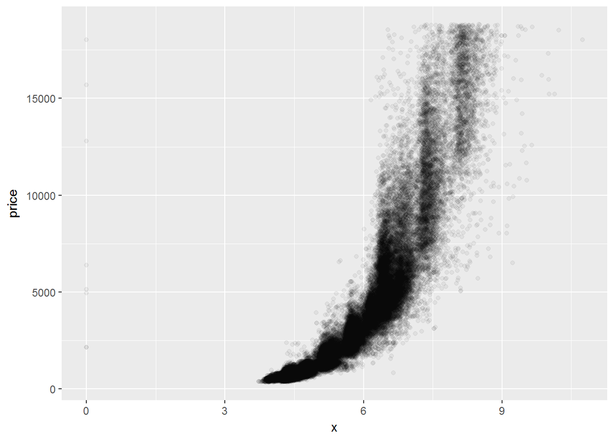

```r
ggplot(data = diamonds, aes(x = x, y = price)) +
  geom_point(alpha = 1/20)
```

#### Notice some outliers and an exponential relationship between price and x

## 2. Find correlation

```r
with(diamonds, cor.test(price,x))
```

```
##
##  Pearson's product-moment correlation
##
## data:  price and x
## t = 440.16, df = 53938, p-value < 2.2e-16
## alternative hypothesis: true correlation is not equal to 0
## 95 percent confidence interval:
##  0.8825835 0.8862594
## sample estimates:
##       cor
## 0.8844352
```

```r
with(diamonds, cor.test(price,y))
```

```
##
##  Pearson's product-moment correlation
##
## data:  price and y
## t = 401.14, df = 53938, p-value < 2.2e-16
## alternative hypothesis: true correlation is not equal to 0
## 95 percent confidence interval:
##  0.8632867 0.8675241
## sample estimates:
##       cor
## 0.8654209
```

```r
with(diamonds, cor.test(price,z))
```

```
##
##  Pearson's product-moment correlation
##
## data:  price and z
## t = 393.6, df = 53938, p-value < 2.2e-16
## alternative hypothesis: true correlation is not equal to 0
## 95 percent confidence interval:
##  0.8590541 0.8634131
## sample estimates:
##       cor
## 0.8612494
```

## 3. Create a simple scatter plot of price vs depth.

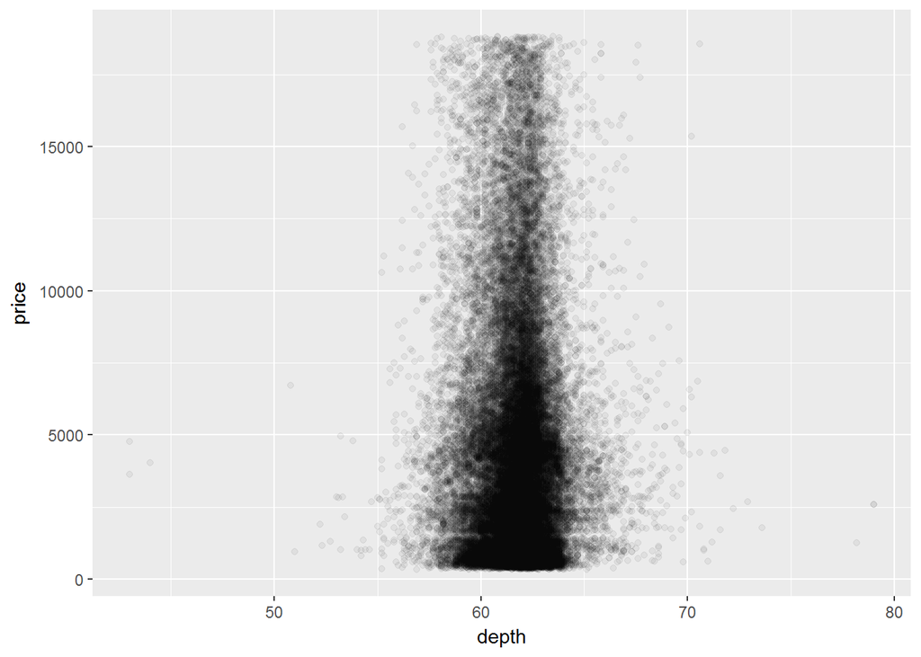

```r
ggplot(data = diamonds, aes(x = depth, y = price))+
  geom_point(alpha = 1/20)
```

## 5. Adjustments - price vs. depth

Change the code to make the transparency of the points to be 1/100 of what they are now and mark the x-axis every 2 units.

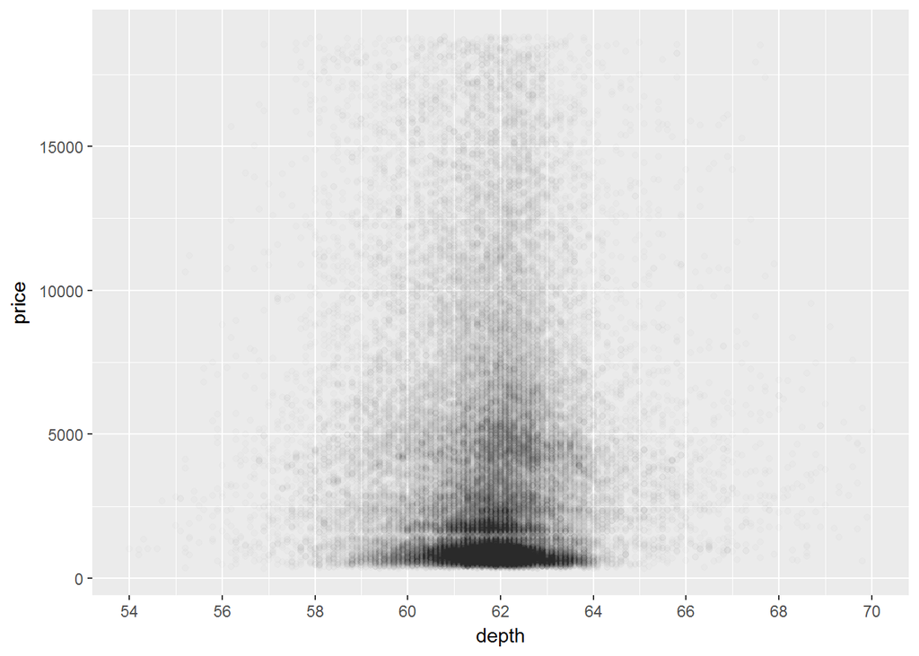

```r
ggplot(data = diamonds, aes(x = depth, y = price))+
  geom_point(alpha = 1/100)+
  scale_x_continuous(breaks = seq(54,70,2), limits = c(54,70))
```

## 7. Correlation - price and depth

```r
with(diamonds, cor.test(price,depth))
```

```
##
##  Pearson's product-moment correlation
##
## data:  price and depth
## t = -2.473, df = 53938, p-value = 0.0134
## alternative hypothesis: true correlation is not equal to 0
## 95 percent confidence interval:
##  -0.019084756 -0.002208537
## sample estimates:
##        cor
## -0.0106474
```

## 8 price vs. carat

Create a scatterplot of price vs carat and omit the top 1% of price and carat values.

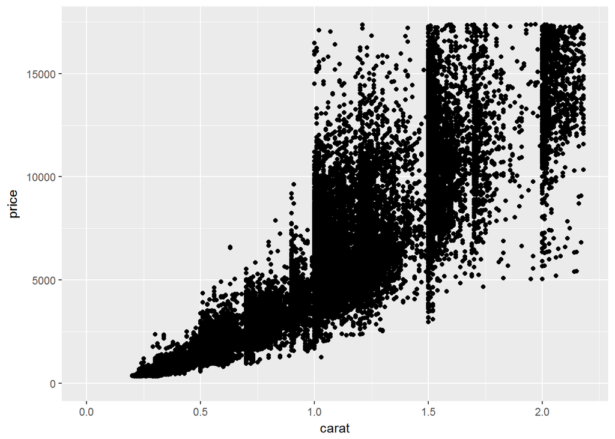

```r
ggplot(data = diamonds, aes(y=price, x=carat))+
  geom_point()+
  ylim(0, quantile(diamonds$price, 0.99))+
  xlim(0, quantile(diamonds$carat, 0.99))
```

## 9. price vs. volume

Create a scatterplot of price vs. volume (x * y * z). Create a new variable for volume in the diamonds data frame.

```r
diamonds <- diamonds %>%
  mutate(volume = x * y * z)
```

```r
str(diamonds)
```

```
## Classes 'tbl_df', 'tbl' and 'data.frame':    53940 obs. of  11 variables:
##  $ carat  : num  0.23 0.21 0.23 0.29 0.31 0.24 0.24 0.26 0.22 0.23 ...
##  $ cut    : Ord.factor w/ 5 levels "Fair"<"Good"<..: 5 4 2 4 2 3 3 3 1 3 ...
##  $ color  : Ord.factor w/ 7 levels "D"<"E"<"F"<"G"<..: 2 2 2 6 7 7 6 5 2 5 ...
##  $ clarity: Ord.factor w/ 8 levels "I1"<"SI2"<"SI1"<..: 2 3 5 4 2 6 7 3 4 5 ...
##  $ depth  : num  61.5 59.8 56.9 62.4 63.3 62.8 62.3 61.9 65.1 59.4 ...
##  $ table  : num  55 61 65 58 58 57 57 55 61 61 ...
##  $ price  : int  326 326 327 334 335 336 336 337 337 338 ...
##  $ x      : num  3.95 3.89 4.05 4.2 4.34 3.94 3.95 4.07 3.87 4 ...
##  $ y      : num  3.98 3.84 4.07 4.23 4.35 3.96 3.98 4.11 3.78 4.05 ...
##  $ z      : num  2.43 2.31 2.31 2.63 2.75 2.48 2.47 2.53 2.49 2.39 ...
##  $ volume : num  38.2 34.5 38.1 46.7 51.9 ...
```

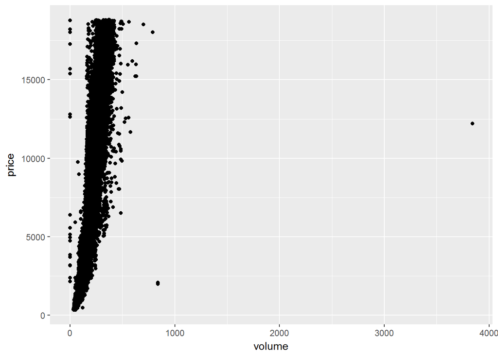

```r
ggplot(data = diamonds, aes(x = volume, y = price))+
  geom_point()
```

Did you notice some outliers? Some volumes are 0! There’s an expensive diamond with a volume near 4000, and a cheaper diamond with a volume near 900.

You can find out how many diamonds have 0 volume by using count(diamonds$volume == 0). The count() function comes with the plyr package.

Note: If you ran the count function from plyr, you need to run this command in R to unload the plyr package.

```
detach("package:plyr", unload=TRUE)
```

The plyr package will conflict with the dplyr package in later exercises.

Depending on your investigation, it may or may not be important for you to understand how outliers, like these, came to be in your data.

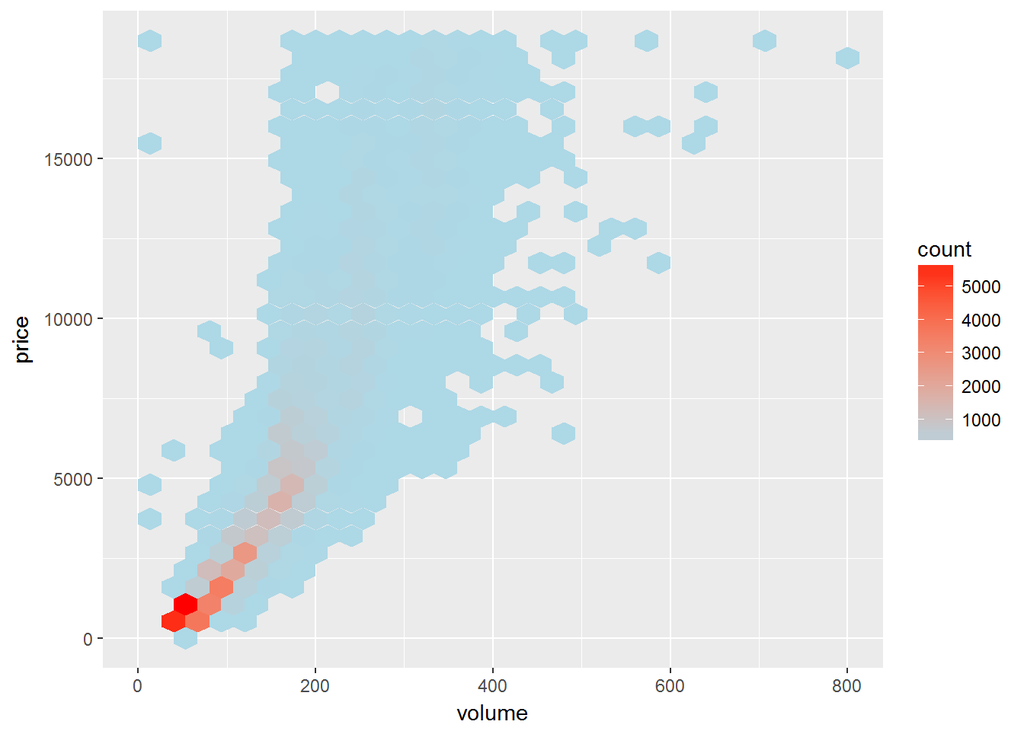

```r
ggplot(data = diamonds, aes(x = volume, y = price))+
  stat_binhex()+
  scale_fill_gradient(low = 'lightblue', high = 'red')+
  xlim(0,800)
```

```r
subd <- subset(diamonds, volume>0 & volume<800 )
with(subd, cor.test(price,volume))
```

```
##
##  Pearson's product-moment correlation
##
## data:  price and volume
## t = 559.19, df = 53915, p-value < 2.2e-16
## alternative hypothesis: true correlation is not equal to 0
## 95 percent confidence interval:
##  0.9222944 0.9247772
## sample estimates:
##       cor
## 0.9235455
```

## Adjustments - price vs. volume

Subset the data to exclude diamonds with a volume greater than or equal to 800. Also, exclude diamonds with a volume of 0. Adjust the transparency of the points and add a linear model to the plot.

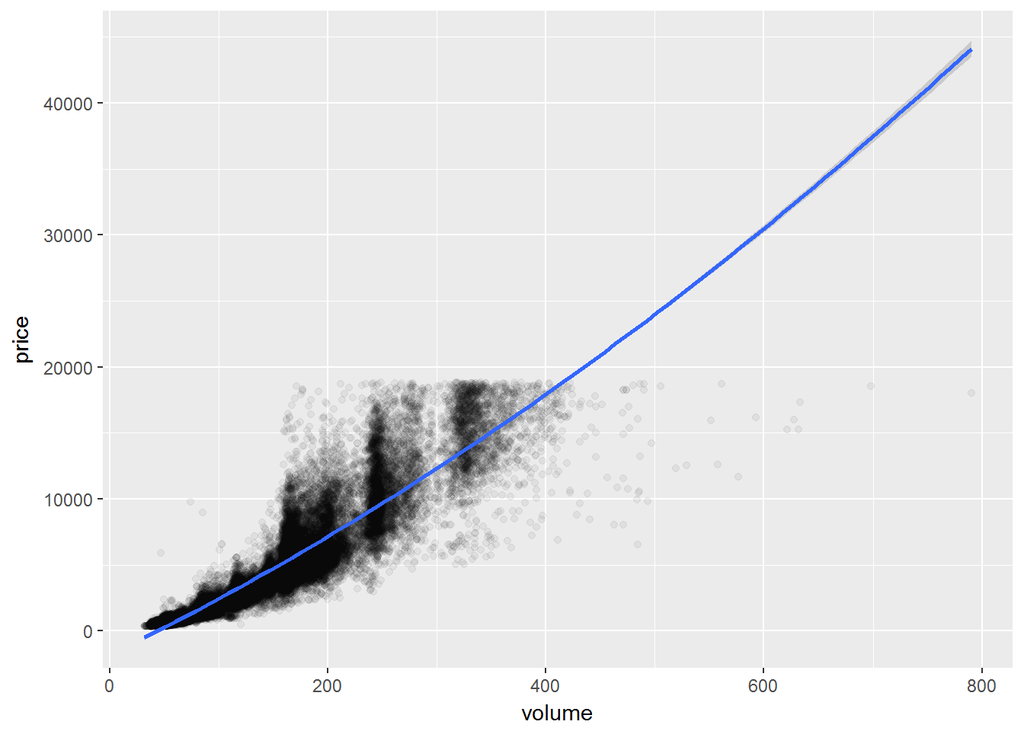

```r
ggplot(data = subd, aes(y = price, x = volume))+
  geom_point(alpha = 1/20)+
  geom_smooth(method = 'lm', formula = y~poly(x,2) )
```

```r
require(mgcv)
library(methods)
```

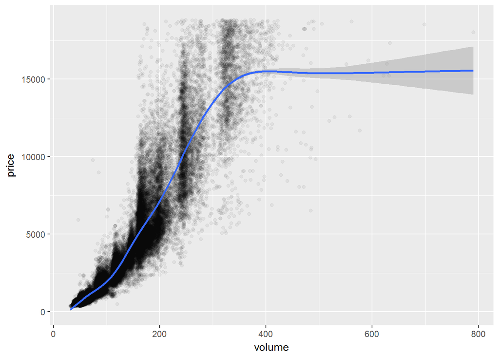

```r
ggplot(data = subd, aes(y = price, x = volume))+
  geom_point(alpha = 1/20)+
  stat_smooth(method = 'gam', formula = y~s(x), size=1 )  # small s
```

## 13 Mean price by clarity

Use the function dplyr package to create a new data frame containing info on diamonds by clarity.

Name the data frame diamondsByClarity The data frame should contain the following variables in this order.

1. mean_price
2. median_price
3. min_price
4. max_price
5. n

where n is the number of diamonds in each level of clarity.

```r
diamondsByClarity <- diamonds %>%
  group_by(clarity) %>%
  summarise(mean_price = mean(price),
            median_price = median(price),
            min_price = min(price),
            max_price = max(price),
            n = n())

head(diamondsByClarity)
```

```
## # A tibble: 6 x 6
##   clarity mean_price median_price min_price max_price     n
##     <ord>      <dbl>        <dbl>     <dbl>     <dbl> <int>
## 1      I1   3924.169         3344       345     18531   741
## 2     SI2   5063.029         4072       326     18804  9194
## 3     SI1   3996.001         2822       326     18818 13065
## 4     VS2   3924.989         2054       334     18823 12258
## 5     VS1   3839.455         2005       327     18795  8171
## 6    VVS2   3283.737         1311       336     18768  5066
```

## 14 Bar Charts of Mean Price

We’ve created summary data frames with the mean price by clarity and color. You can run the code in R to verify what data is in the variables diamonds_mp_by_clarity and diamonds_mp_by_color.

Your task is to write additional code to create two bar plots on one output image using the grid.arrange() function from the package gridExtra.

```r
diamonds_by_clarity <- group_by(diamonds, clarity)
diamonds_mp_by_clarity <- summarise(diamonds_by_clarity, mean_price = mean(price))

diamonds_by_color <- group_by(diamonds, color)
diamonds_mp_by_color <- summarise(diamonds_by_color, mean_price = mean(price))

diamonds_mp_by_cut <- diamonds %>%
  group_by(cut) %>%
  summarise(mean_price = mean(price))
```

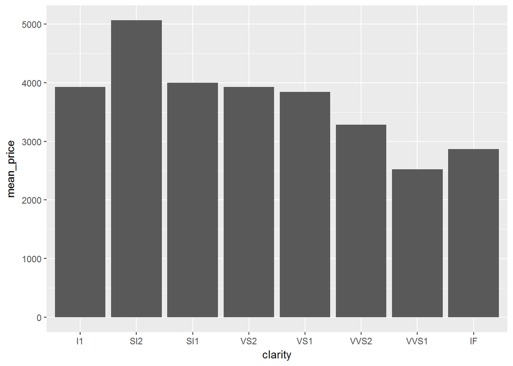

```r
p1 <- ggplot(data = diamonds_mp_by_clarity, aes(x = clarity, y = mean_price)) +
  geom_col()

p1
```

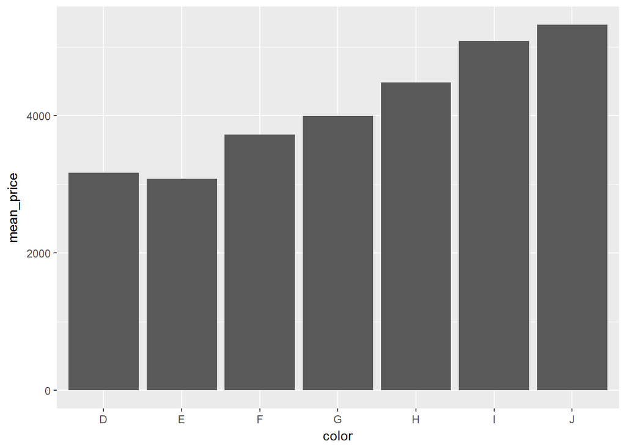

```r
p2 <- ggplot(data = diamonds_mp_by_color, aes(x = color, y = mean_price)) +
  geom_col()
p2
```

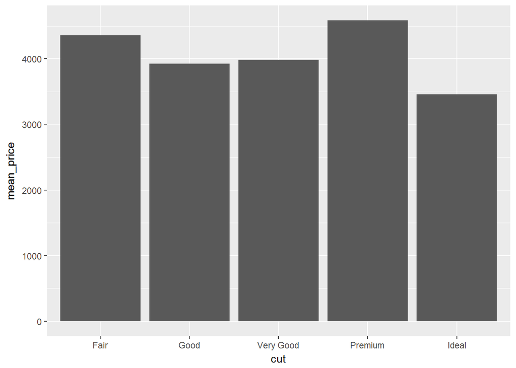

```r
p3 <- ggplot(data = diamonds_mp_by_cut, aes(x = cut, y = mean_price))+
  geom_col()

p3
```

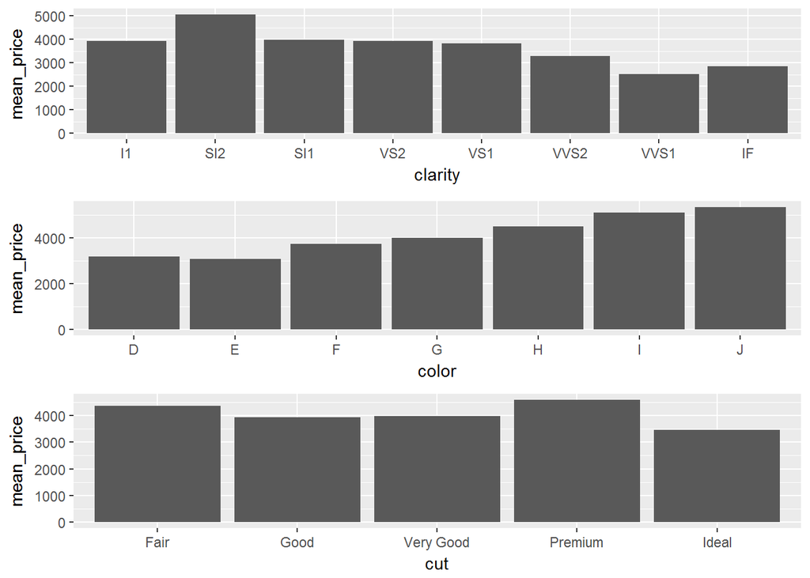

```r
grid.arrange(p1,p2,p3,ncol=1)
```

Observe : think something odd is going here. These trends seem to go against our intuition.

**Mean price tends to decrease as clarity improves. The same can be said for color.**

## 16 [Gapminder Revisited](http://www.gapminder.org/data/)

examine pairs of variable and create 2-5 plots that make use of the techniques from Lesson 4.

```r
# Loading libraries
suppressMessages(library(xlsx))
library(rJava)
library(xlsxjars)
```

```r
female_bmi <- read.xlsx('Indicator_BMI female ASM.xlsx', sheetName = 'Data', header = TRUE)
male_bmi <- read.xlsx('Indicator_BMI male ASM.xlsx', sheetName = 'Data', header = TRUE)
```

### Selecting countries in which i am interested

```r
fm_bmi <- filter(female_bmi, Country %in% c('Bangladesh', 'India', 'Pakistan', 'Russia', 'United Kingdom', 'United States', 'United Arab Emirates'))
m_bmi <- filter(male_bmi, Country %in% c('Bangladesh', 'India', 'Pakistan', 'Russia', 'United Kingdom', 'United States', 'United Arab Emirates') )
#rm(female_bmi,male_bmi)
```

### Selecting only India

```r
fm_india <- subset(fm_bmi, Country == 'India')
fm_india_tr <- data.frame(t(fm_india))
rm(fm_india)

m_india <- subset(m_bmi, Country == 'India')
m_india_tr <- data.frame(t(m_india))
rm(m_india)
```

```
# Alternative for turning rownames into a column
# load data table
library(data.table)
# create datable from dataframe
setDT(transposed_data, keep.rownames = TRUE)[]
# rename the first column to 'Year'
names(transposed_data)[[1]] <- "Year"
```

#### [Difference between data.frame() and as.data.frame()](https://stackoverflow.com/questions/21574250/difference-between-as-data-framex-and-data-framex)

#### [How to change a character of each elememt of a column](https://stackoverflow.com/questions/21187603/replace-characters-from-a-column-of-a-data-frame-r)

```
Tried to replace 'X1998' to '1998'
```

## Female BMI india

```r
library(data.table)
setDT(fm_india_tr, keep.rownames = TRUE)[]
```

```
##          rn       X2
##  1: Country    India
##  2:   X1980 20.48016
##  3:   X1981 20.48859
##  4:   X1982 20.49665
##  5:   X1983 20.51533
##  6:   X1984 20.52994
##  7:   X1985 20.54383
##  8:   X1986 20.55028
##  9:   X1987 20.56082
## 10:   X1988 20.58607
## 11:   X1989 20.61284
## 12:   X1990 20.62835
## 13:   X1991 20.64419
## 14:   X1992 20.67087
```

[output cut: 17 more lines]

```r
names(fm_india_tr)[[1]] <- "Years"
fm_india_tr <- fm_india_tr[2:30, ]
fm_india_tr$Years <- gsub('X','',fm_india_tr$Years)   # to remove 'X' from each element of column from 'X2000' to '2000'
names(fm_india_tr)[[2]] <- "Female_BMI"
head(fm_india_tr)
```

```
##    Years Female_BMI
## 1:  1980   20.48016
## 2:  1981   20.48859
## 3:  1982   20.49665
## 4:  1983   20.51533
## 5:  1984   20.52994
## 6:  1985   20.54383
```

```r
str(fm_india_tr)
```

```
## Classes 'data.table' and 'data.frame':   29 obs. of  2 variables:
##  $ Years     : chr  "1980" "1981" "1982" "1983" ...
##  $ Female_BMI: Factor w/ 30 levels "20.48016","20.48859",..: 1 2 3 4 5 6 7 8 9 10 ...
##  - attr(*, ".internal.selfref")=<externalptr>
```

[To convert from a factor array to a numeric array or conversion b/w different data types](http://www.cookbook-r.com/Manipulating_data/Converting_between_vector_types/) The way to get the text values converted to numbers is to first convert it to a character, then a numeric vector.

```r
fm_india_tr$Years <- as.numeric(as.character(fm_india_tr$Years))
fm_india_tr$Female_BMI <- as.numeric(as.character(fm_india_tr$Female_BMI))
str(fm_india_tr)
```

```
## Classes 'data.table' and 'data.frame':   29 obs. of  2 variables:
##  $ Years     : num  1980 1981 1982 1983 1984 ...
##  $ Female_BMI: num  20.5 20.5 20.5 20.5 20.5 ...
##  - attr(*, ".internal.selfref")=<externalptr>
```

## Male BMI India

```r
setDT(m_india_tr, keep.rownames = TRUE)[]
```

```
##          rn       X2
##  1: Country    India
##  2:   X1980 21.09132
##  3:   X1981 21.04581
##  4:   X1982 21.00317
##  5:   X1983 20.96066
##  6:   X1984 20.92134
##  7:   X1985 20.88185
##  8:   X1986 20.84291
##  9:   X1987 20.80062
## 10:   X1988 20.76272
## 11:   X1989 20.72949
## 12:   X1990  20.7024
## 13:   X1991 20.67306
## 14:   X1992 20.64642
```

[output cut: 17 more lines]

```r
names(m_india_tr)[[1]] <- "Years"
m_india_tr <- m_india_tr[2:30, ]
m_india_tr$Years <- gsub('X','',m_india_tr$Years)   # to remove 'X' from each element of column from 'X2000' to '2000'
names(m_india_tr)[[2]] <- "Male_BMI"
head(m_india_tr)
```

```
##    Years Male_BMI
## 1:  1980 21.09132
## 2:  1981 21.04581
## 3:  1982 21.00317
## 4:  1983 20.96066
## 5:  1984 20.92134
## 6:  1985 20.88185
```

```r
m_india_tr$Years <- as.numeric(as.character(m_india_tr$Years))
m_india_tr$Male_BMI <- as.numeric(as.character(m_india_tr$Male_BMI))
str(m_india_tr)
```

```
## Classes 'data.table' and 'data.frame':   29 obs. of  2 variables:
##  $ Years   : num  1980 1981 1982 1983 1984 ...
##  $ Male_BMI: num  21.1 21 21 21 20.9 ...
##  - attr(*, ".internal.selfref")=<externalptr>
```

## Merging the 2 dataframes m_india_tr and fm_india_tr to India_BMI with help of Years column

```r
India_BMI <- merge(m_india_tr, fm_india_tr, by = "Years")
head(India_BMI)
```

```
##    Years Male_BMI Female_BMI
## 1:  1980 21.09132   20.48016
## 2:  1981 21.04581   20.48859
## 3:  1982 21.00317   20.49665
## 4:  1983 20.96066   20.51533
## 5:  1984 20.92134   20.52994
## 6:  1985 20.88185   20.54383
```

## Making line graph with multiple lines

```r
Indiag_BMI <- gather(India_BMI, key = 'Gender', value = 'BMI', Male_BMI, Female_BMI)
head(Indiag_BMI,10)
```

```
##    Years   Gender      BMI
## 1   1980 Male_BMI 21.09132
## 2   1981 Male_BMI 21.04581
## 3   1982 Male_BMI 21.00317
## 4   1983 Male_BMI 20.96066
## 5   1984 Male_BMI 20.92134
## 6   1985 Male_BMI 20.88185
## 7   1986 Male_BMI 20.84291
## 8   1987 Male_BMI 20.80062
## 9   1988 Male_BMI 20.76272
## 10  1989 Male_BMI 20.72949
```

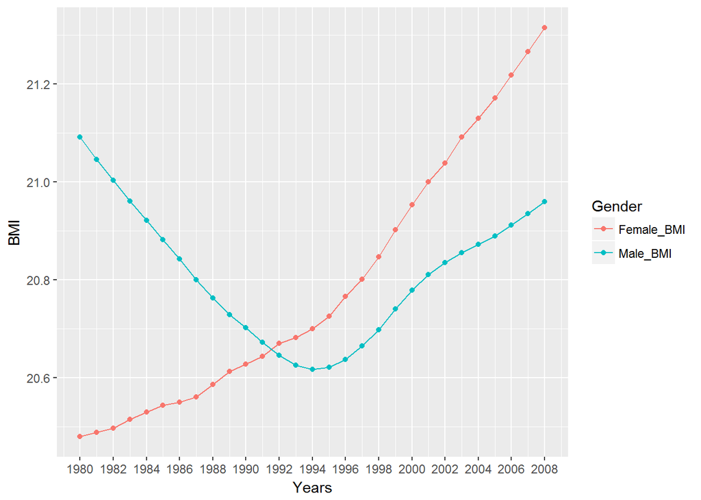

```r
ggplot(data = Indiag_BMI, aes(x = Years, y = BMI, group = Gender, color = Gender))+
  geom_line()+
  geom_point()+
  scale_x_continuous(limits = c(1980,2008), breaks = seq(1980,2008,2))
```

### Plotting BMI for males of selected countries

**m_bmi dataframe**

```r
m_bmi <- m_bmi %>%
  gather(key = 'Years', value = 'BMI', 2:30 )
m_bmi$Years <- gsub('X','',m_bmi$Years)
```

Comparing BMI of males of the selected countries

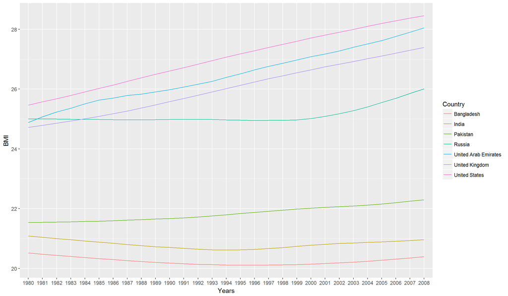

```r
ggplot(data = m_bmi, aes(x = Years, y = BMI))+
  geom_line(aes(color = Country, group = Country))
```

```r
#ggsave('male_bmi.png')
```

From the graph, we see that US, UAE and UK have the highest male BMI and it is increasing at a steady rate from 1980. In case of Russia the BMI of males remained almost constant till 2000 and then it started increasing . COuntries like Pakistan, India and Bangladesh had comparatively lower BMI.

#### Comparing BMI of females of the selected countries

**fm_bmi**

```r
fm_bmi <- fm_bmi %>%
  gather(key = 'Years', value = 'BMI', 2:30)
fm_bmi$Years <- gsub('X','',fm_bmi$Years)
```

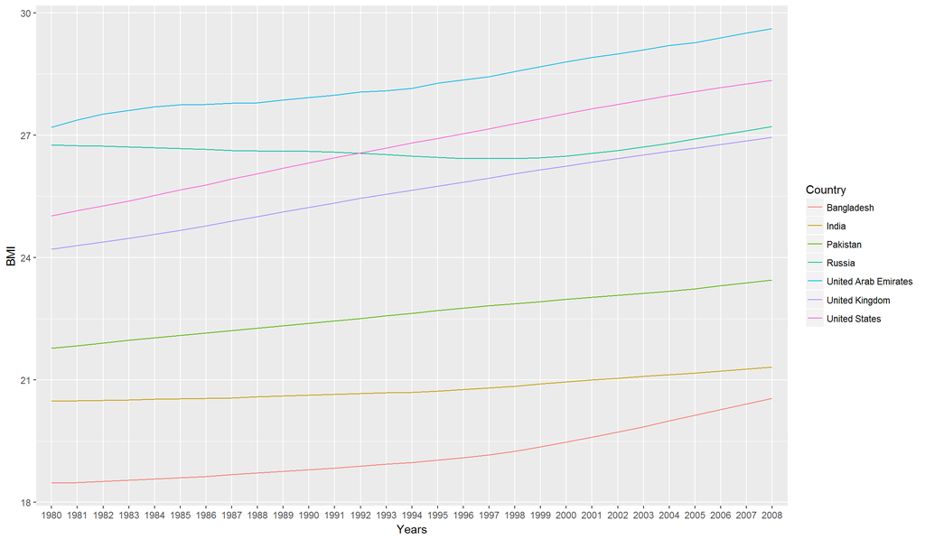

```r
ggplot(data = fm_bmi, aes(x = Years, y = BMI))+
  geom_line(aes(color = Country, group = Country))
```

```r
#ggsave('female_bmi.png')
```

For female : From fig, BMI of UAE is higher than other countries. Earlier in 1980s BMI of Russia was higher than that of US but after 1992 BMI of US increased at a ateady rate as compared to that of russia whose BMI decreased comparatively during that time and is increasing steadily after that.

# Additional Graphs

### What is the BMI over time all over the world?

Converting to long format form.

```r
male_bmi <- male_bmi %>%
  gather(key = 'Years', value = 'BMI', 2:30)
male_bmi$Years <- gsub('X','',male_bmi$Years)

female_bmi <- female_bmi %>%
  gather(key = 'Years', value = 'BMI', 2:30)
female_bmi$Years <- gsub('X','',female_bmi$Years)
```

### For males

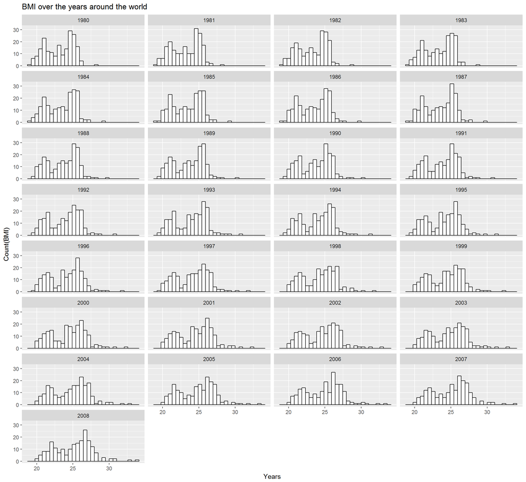

```r
ggplot(data = male_bmi, aes(x = BMI)) +
  geom_histogram(color = 'black', fill = 'white')+
  facet_wrap( ~ Years, ncol = 4)+
  labs(title = 'BMI over the years around the world', x = 'Years', y =  'Count(BMI)' )
```

Over the years, the histograms seem to follow a bimodal distribution.